# ubiquitine verschillende analyses

```r
library(tidyverse)
library(MSstatsPTM)
library(QFeatures)
library(msqrob2)
library(gt)
library(seqinr)
library(data.table)
library(lme4)
load("usp30_input_data.rda")
```

```r
#In here PTM level and Protein level data
head(raw_input_data)
```

| protein | peptide | is_mod | feature | group | batch | run | log2inty | site |
| --- | --- | --- | --- | --- | --- | --- | --- | --- |
| A0A024QZJ1 | KTGTQQELDGVFQK*LGNLK | TRUE | KTGTQQELDGVFQK*LGNLK_3 | CCCP | BCH2 | CCCP-B2T1 | 19.79943 | K071 |
| A0A024QZJ1 | KTGTQQELDGVFQK*LGNLK | TRUE | KTGTQQELDGVFQK*LGNLK_3 | CCCP | BCH2 | CCCP-B2T2 | 19.61631 | K071 |
| A0A024QZJ1 | KTGTQQELDGVFQK*LGNLK | TRUE | KTGTQQELDGVFQK*LGNLK_3 | Combo | BCH2 | Combo-B2T1 | 20.14078 | K071 |
| A0A024QZJ1 | KTGTQQELDGVFQK*LGNLK | TRUE | KTGTQQELDGVFQK*LGNLK_3 | Combo | BCH2 | Combo-B2T2 | 19.97846 | K071 |
| A0A024QZJ1 | KTGTQQELDGVFQK*LGNLK | TRUE | KTGTQQELDGVFQK*LGNLK_3 | Ctrl | BCH2 | Ctrl-B2T1 | 18.64700 | K071 |
| A0A024QZJ1 | KTGTQQELDGVFQK*LGNLK | TRUE | KTGTQQELDGVFQK*LGNLK_3 | Ctrl | BCH2 | Ctrl-B2T2 | 19.78290 | K071 |

# 1 MSstatsPTM analysis

The MSstats workflow and the input data was found on Massive: https://massive.ucsd.edu/ProteoSAFe/dataset_files.jsp?task=f9e6117e00794ce5b2e8802601be16bc#%7B%22table_sort_history%22%3A%22main.collection_asc%22%7D

```r
## Convert to MSstatsPTM input format
raw_input_data$FragmentIon <- NA
raw_input_data$ProductCharge <- NA
raw_input_data$IsotopeLabelType <- 'L'
raw_input_data <- raw_input_data %>%
  mutate(PrecursorCharge = stringr::str_split(
    raw_input_data$feature, "_", simplify = TRUE)[,2])

colnames(raw_input_data) <- c('ProteinName', 'PeptideSequence', 'is_mod', 'Feature',
                            'Condition', "Batch", "Run", 'Intensity', 'site', 'FragmentIon',
                            'ProductCharge', 'IsotopeLabelType', 'PrecursorCharge')

raw_input_data$BioReplicate <- raw_input_data$Batch
raw_input_data$Intensity <- 2^raw_input_data$Intensity
```

```r
## Split modified and unmodified peptides
PTM_df <- raw_input_data %>% filter(is_mod == TRUE)
PTM_df$ProteinName <- paste(PTM_df$ProteinName, PTM_df$site, sep = '_')
protein_df <- raw_input_data %>% filter(is_mod == FALSE)
```

```r
## Remove unneeded columns
drops <- c("is_mod", "site", "Batch", "Feature")
PTM_df <- PTM_df[ , !(names(PTM_df) %in% drops)]
protein_df <- protein_df[ , !(names(protein_df) %in% drops)]

input_df <- list('PTM' = PTM_df, 'PROTEIN' = protein_df)
```

## 1.1 summarisation

```r
## Summarize features
summarized_ptm <- dataSummarizationPTM(input_df, verbose = F)
```

```
## Starting PTM summarization...
```

```
## Starting Protein summarization...
```

```r
## Model summarized results
## Full pairwise comparison used
model_ptm <- groupComparisonPTM(summarized_ptm, data.type = "LabelFree")
```

```
## Starting PTM modeling...
```

```
## INFO  [2023-05-22 13:15:04]  == Start to test and get inference in whole plot ...
##
```

```
##
## INFO  [2023-05-22 13:24:44]  == Comparisons for all proteins are done.
```

```
## Starting Protein modeling...
```

```
## INFO  [2023-05-22 13:24:46]  == Start to test and get inference in whole plot ...
##
```

```
##
## INFO  [2023-05-22 13:25:45]  == Comparisons for all proteins are done.
```

```
## Starting adjustment...
```

```r
save(summarized_ptm, file ="C:/Users/Nina/OneDrive - UGent/Documenten/Doctoraat/msqrobPTM/Datasets MSStats/Biological dataset Ubiquitination MSV000078977/Quant analysis Massive/MSstatsSummarizedData.RData")
save(model_ptm, file = "C:/Users/Nina/OneDrive - UGent/Documenten/Doctoraat/msqrobPTM/Datasets MSStats/Biological dataset Ubiquitination MSV000078977/Quant analysis Massive/MSstatsModel.rda")
```

# 2 Msqrob2PTM analysis

## 2.1 Start from raw data

```r
load("usp30_input_data.rda")
raw_input_data <- raw_input_data %>% arrange(run)
pepform_df <- pivot_wider(raw_input_data, id_cols = c("protein", "peptide", "feature", "site"),
                           names_from = "run", values_from = "log2inty")
```

```r
head(pepform_df, 10)
```

| protein | peptide | feature | site | CCCP-B1T1 | CCCP-B1T2 | CCCP-B2T1 | CCCP-B2T2 | Combo-B1T1 | Combo-B1T2 | Combo-B2T1 | Combo-B2T2 | Ctrl-B1T1 | Ctrl-B1T2 | Ctrl-B2T1 | Ctrl-B2T2 | USP30_OE-B1T1 | USP30_OE-B1T2 | USP30_OE-B2T1 | USP30_OE-B2T2 |
| --- | --- | --- | --- | --- | --- | --- | --- | --- | --- | --- | --- | --- | --- | --- | --- | --- | --- | --- | --- |
| A0A024QZJ1 | KTGTQQELDGVFQKLGNLK* | KTGTQQELDGVFQKLGNLK*_4 | K076 | 22.55966 | 22.14408 | NA | 18.23597 | NA | NA | NA | 21.95786 | 23.16497 | 22.98019 | 20.96109 | 21.39999 | 23.45793 | 23.25786 | 21.22163 | NA |
| A0A024QZJ1 | TGTQQELDGVFQK*LGNLK | TGTQQELDGVFQK*LGNLK_3 | K071 | 22.32460 | 23.33117 | 21.13594 | 21.08831 | 23.76914 | 23.97097 | 21.96042 | 21.80823 | 24.23907 | 24.40052 | 20.34813 | 20.74042 | 24.34247 | 24.27829 | 21.16379 | 21.21113 |
| A0A024R1P8 | MLAFLGAVICIIASVPLAASPAR | MLAFLGAVICIIASVPLAASPAR_4 | None | 28.38777 | 27.99339 | NA | NA | 27.74200 | 27.62278 | NA | NA | 30.36530 | 30.28850 | NA | NA | 30.19105 | 30.06184 | NA | NA |
| A0A024R3R5 | NTQEK*FNLSQESSYIATQYSLRPR | NTQEK*FNLSQESSYIATQYSLRPR_4 | K152 | 25.60518 | 25.70952 | NA | NA | 26.12399 | 25.91336 | NA | NA | 22.73655 | 23.00100 | NA | NA | 22.54652 | 22.62275 | NA | NA |
| A0A024R4U1 | VEPWRAGPGR | VEPWRAGPGR_2 | None | 23.88118 | 23.90743 | NA | NA | 24.21416 | 23.91717 | NA | NA | 23.75984 | 23.72253 | NA | NA | 23.76444 | 23.78575 | NA | NA |
| A0A024R592 | AKETQGK* | AKETQGK*_2 | K120 | 19.46793 | 19.67326 | NA | NA | 19.75811 | 19.89514 | NA | NA | NA | NA | NA | NA | NA | 17.56666 | NA | NA |
| A0A024R5E0 | MLFQCSLPDTTATLGDEPRK | MLFQCSLPDTTATLGDEPRK_4 | None | 24.15755 | 24.22947 | NA | NA | 24.82450 | 24.80161 | NA | NA | NA | NA | NA | NA | NA | NA | NA | NA |
| A0A024R6W0 | GMADRIIGMR | GMADRIIGMR_2 | None | 22.99395 | 22.98108 | NA | NA | 22.95169 | 22.78362 | NA | NA | 23.13121 | 22.88988 | NA | NA | 23.21290 | 22.82128 | NA | NA |
| A0A024RC47 | QELPSALESHEVPGTLSMGVPQIFK*YGETCFPK | QELPSALESHEVPGTLSMGVPQIFK*YGETCFPK_4 | K228 | 21.67271 | 22.19355 | NA | NA | NA | 21.45129 | NA | NA | 22.19512 | NA | NA | NA | 23.02874 | 22.84698 | NA | NA |
| A0A087WTF2 | AVGEMCK*GPGAAR | AVGEMCK*GPGAAR_3 | K94 | 21.30682 | 21.03055 | 21.80274 | 21.81135 | 21.45060 | 21.32635 | 21.68968 | 21.86243 | 23.02924 | 23.42246 | 22.85649 | 22.86786 | 23.04538 | 23.12040 | 22.86385 | 22.86478 |

```r
pepform_df = pepform_df %>%
                  mutate(site = case_when(site == "None" ~ "",
                        TRUE ~ site)) %>%
                  mutate(ptm = case_when(
                    site != "" ~ paste(protein, site, sep = "_"),
                        TRUE ~ ""))
head(pepform_df, 20)
```

| protein | peptide | feature | site | CCCP-B1T1 | CCCP-B1T2 | CCCP-B2T1 | CCCP-B2T2 | Combo-B1T1 | Combo-B1T2 | Combo-B2T1 | Combo-B2T2 | Ctrl-B1T1 | Ctrl-B1T2 | Ctrl-B2T1 | Ctrl-B2T2 | USP30_OE-B1T1 | USP30_OE-B1T2 | USP30_OE-B2T1 | USP30_OE-B2T2 | ptm |
| --- | --- | --- | --- | --- | --- | --- | --- | --- | --- | --- | --- | --- | --- | --- | --- | --- | --- | --- | --- | --- |
| A0A024QZJ1 | KTGTQQELDGVFQKLGNLK* | KTGTQQELDGVFQKLGNLK*_4 | K076 | 22.55966 | 22.14408 | NA | 18.23597 | NA | NA | NA | 21.95786 | 23.16497 | 22.98019 | 20.96109 | 21.39999 | 23.45793 | 23.25786 | 21.22163 | NA | A0A024QZJ1_K076 |
| A0A024QZJ1 | TGTQQELDGVFQK*LGNLK | TGTQQELDGVFQK*LGNLK_3 | K071 | 22.32460 | 23.33117 | 21.13594 | 21.08831 | 23.76914 | 23.97097 | 21.96042 | 21.80823 | 24.23907 | 24.40052 | 20.34813 | 20.74042 | 24.34247 | 24.27829 | 21.16379 | 21.21113 | A0A024QZJ1_K071 |
| A0A024R1P8 | MLAFLGAVICIIASVPLAASPAR | MLAFLGAVICIIASVPLAASPAR_4 |  | 28.38777 | 27.99339 | NA | NA | 27.74200 | 27.62278 | NA | NA | 30.36530 | 30.28850 | NA | NA | 30.19105 | 30.06184 | NA | NA |  |
| A0A024R3R5 | NTQEK*FNLSQESSYIATQYSLRPR | NTQEK*FNLSQESSYIATQYSLRPR_4 | K152 | 25.60518 | 25.70952 | NA | NA | 26.12399 | 25.91336 | NA | NA | 22.73655 | 23.00100 | NA | NA | 22.54652 | 22.62275 | NA | NA | A0A024R3R5_K152 |
| A0A024R4U1 | VEPWRAGPGR | VEPWRAGPGR_2 |  | 23.88118 | 23.90743 | NA | NA | 24.21416 | 23.91717 | NA | NA | 23.75984 | 23.72253 | NA | NA | 23.76444 | 23.78575 | NA | NA |  |
| A0A024R592 | AKETQGK* | AKETQGK*_2 | K120 | 19.46793 | 19.67326 | NA | NA | 19.75811 | 19.89514 | NA | NA | NA | NA | NA | NA | NA | 17.56666 | NA | NA | A0A024R592_K120 |
| A0A024R5E0 | MLFQCSLPDTTATLGDEPRK | MLFQCSLPDTTATLGDEPRK_4 |  | 24.15755 | 24.22947 | NA | NA | 24.82450 | 24.80161 | NA | NA | NA | NA | NA | NA | NA | NA | NA | NA |  |
| A0A024R6W0 | GMADRIIGMR | GMADRIIGMR_2 |  | 22.99395 | 22.98108 | NA | NA | 22.95169 | 22.78362 | NA | NA | 23.13121 | 22.88988 | NA | NA | 23.21290 | 22.82128 | NA | NA |  |
| A0A024RC47 | QELPSALESHEVPGTLSMGVPQIFK*YGETCFPK | QELPSALESHEVPGTLSMGVPQIFK*YGETCFPK_4 | K228 | 21.67271 | 22.19355 | NA | NA | NA | 21.45129 | NA | NA | 22.19512 | NA | NA | NA | 23.02874 | 22.84698 | NA | NA | A0A024RC47_K228 |
| A0A087WTF2 | AVGEMCK*GPGAAR | AVGEMCK*GPGAAR_3 | K94 | 21.30682 | 21.03055 | 21.80274 | 21.81135 | 21.45060 | 21.32635 | 21.68968 | 21.86243 | 23.02924 | 23.42246 | 22.85649 | 22.86786 | 23.04538 | 23.12040 | 22.86385 | 22.86478 | A0A087WTF2_K94 |

[output cut: 10 more lines]

### 2.1.1 Transform into QFeatures object

```r
#order dataframe by protein, for the normalisation step
pepform_df = pepform_df[order(pepform_df$protein),]
pe <- readQFeatures(pepform_df,ecol= 5:20,name="peptidoformRaw", fnames = "feature")
```

```r
colData(pe)$group <- sapply(str_split(rownames(colData(pe)), "-"), function(x) x[1])
colData(pe)$biorep <- gsub("T[0-9]", "", rownames(colData(pe)))
colData(pe)$techrep <- rownames(colData(pe))

colData(pe)$group <- relevel(as.factor(colData(pe)$group), ref="Ctrl")
colData(pe)$biorep <- as.factor(colData(pe)$biorep)
colData(pe)$techrep <- as.factor(colData(pe)$techrep)

colData(pe)
```

```
## DataFrame with 16 rows and 3 columns
##                  group      biorep       techrep
##               <factor>    <factor>      <factor>
## CCCP-B1T1        CCCP     CCCP-B1     CCCP-B1T1
## CCCP-B1T2        CCCP     CCCP-B1     CCCP-B1T2
## CCCP-B2T1        CCCP     CCCP-B2     CCCP-B2T1
## CCCP-B2T2        CCCP     CCCP-B2     CCCP-B2T2
## Combo-B1T1       Combo    Combo-B1    Combo-B1T1
## ...                ...         ...           ...
## Ctrl-B2T2     Ctrl     Ctrl-B2     Ctrl-B2T2
## USP30_OE-B1T1 USP30_OE USP30_OE-B1 USP30_OE-B1T1
## USP30_OE-B1T2 USP30_OE USP30_OE-B1 USP30_OE-B1T2
## USP30_OE-B2T1 USP30_OE USP30_OE-B2 USP30_OE-B2T1
## USP30_OE-B2T2 USP30_OE USP30_OE-B2 USP30_OE-B2T2
```

### 2.1.2 Preprocessing

```r
print(nrow(pe[["peptidoformRaw"]]))
```

```
## [1] 20304
```

```r
rowData(pe[["peptidoformRaw"]])$nNonZero <- rowSums(assay(pe[["peptidoformRaw"]]) > 0, na.rm = T)
pe <- zeroIsNA(pe, i = "peptidoformRaw")
pe <- pe[rowData(pe[["peptidoformRaw"]])$nNonZero>2,,]
pe <- normalize(pe, i = "peptidoformRaw", method = "center.median", name = "peptidoform")
print(nrow(pe[["peptidoform"]]))
```

```
## [1] 18520
```

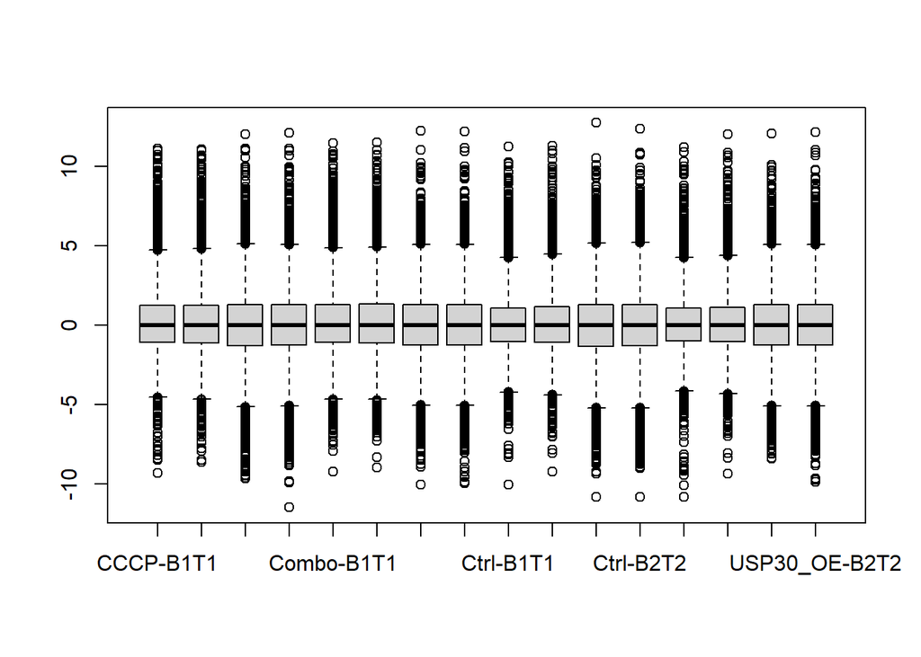

```r
boxplot(assay(pe[["peptidoform"]]))
```

### 2.1.3 Normalize pepform log intensity by protein log intensity

First one is for visualisation purposes

```r
pe <- aggregateFeatures(pe,
 i = "peptidoformRaw",
 fcol = "protein",
 na.rm = TRUE,
 name = "proteinRaw",
 fun = MsCoreUtils::robustSummary)
```

```
## Your quantitative data contain missing values. Please read the relevant
## section(s) in the aggregateFeatures manual page regarding the effects
## of missing values on data aggregation.
```

```r
pe <- aggregateFeatures(pe,
 i = "peptidoform",
 fcol = "protein",
 na.rm = TRUE,
 name = "proteinRobust",
 fun = MsCoreUtils::robustSummary)
```

```
## Your quantitative data contain missing values. Please read the relevant
## section(s) in the aggregateFeatures manual page regarding the effects
## of missing values on data aggregation.
```

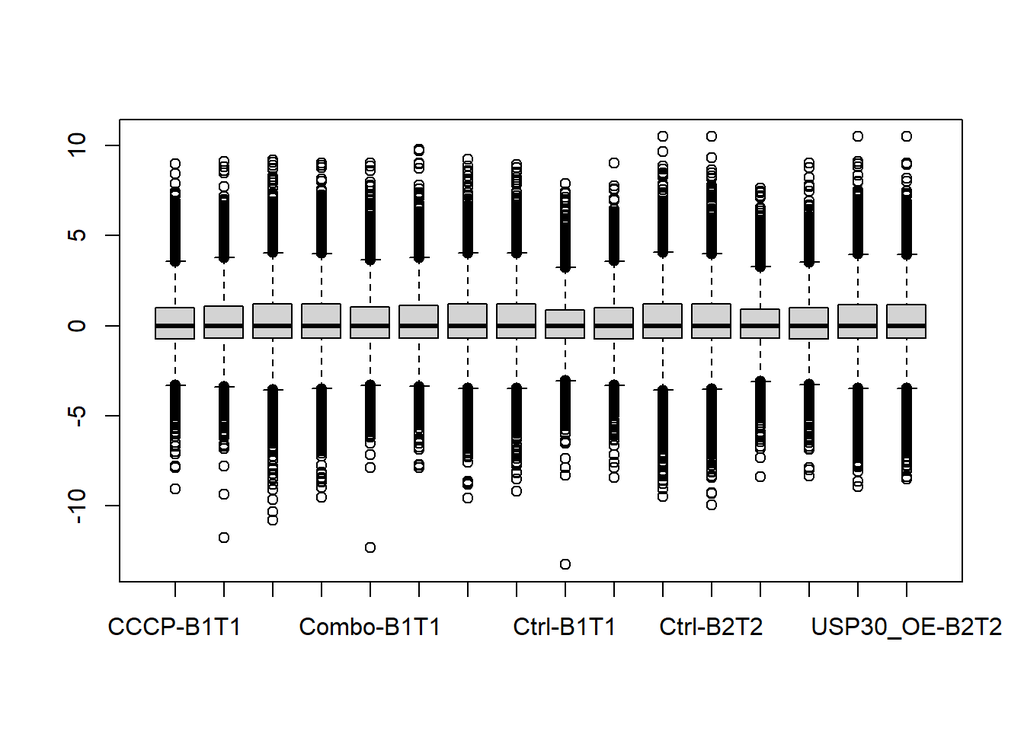

```r
#Only take pepforms that have a parent protein
#(when there is no global profiling dataset, this will be all peptidoforms)
pepWithProtein <- rowData(pe[["peptidoform"]])$protein %in% rownames(pe[["proteinRobust"]])
pepepWithProtein  <- pe[["peptidoform"]][pepWithProtein,]
pe <- addAssay(pe,pepepWithProtein,"pepformRel")
#normalisation for protein abundance step
assay(pe[["pepformRel"]]) <- assay(pe[["pepformRel"]]) - assay(pe[["proteinRobust"]])[rowData(pe[["pepformRel"]])$protein,colnames(assay(pe[["pepformRel"]]))]
boxplot(assay(pe[["pepformRel"]]))
```

### 2.1.4 ptm summarisatie

Summarise peptidoforms to ptm level

#### 2.1.4.1 Get ptm level intensity matrix

Get matrix for DPTMx -> get summarised intensity values

```r
ptms <- unique(as.vector(rowData(pe[["pepformRel"]])$ptm))
ptms <- ptms[-c(which(ptms==""))]
```

```r
#For each ptm do
ptm_x_assay <- sapply(unique(ptms), function(i){
  #print(i)
  #Get current protein and mod from ptm
  #This is pretty straightforward here because there is only 1 ptm per peptidoform
  ptm_sub <- pe[["pepformRel"]][grepl(i, rowData(pe[["pepformRel"]])$ptm, fixed = T),]
  #ptm_sub <- filterFeatures(pe,~grepl(ptm,pattern=i, fixed=T))[["peptidoformNorm"]]
  #Get intensity values of those peptidoforms
  z <- assay(ptm_sub)
  z <- filter(as.data.frame(z), rowSums(is.na(z) | z==0) != ncol(z))
  #And summarise them to 1 row of intensity values: 1 value per sample for that ptm
  ptm_y <- try(MsCoreUtils::robustSummary(as.matrix(z)), silent = T)
  if (is(ptm_y, "try-error"))
  {ptm_y <- matrix(rep(NA,ncol(ptm_sub)), nrow = 1,
                     dimnames = list(c(i), c(colnames(ptm_sub))))}

  ptm_y
})
#Then we get the intensity assay on ptm level
ptm_x_assay <- t(ptm_x_assay)
#rownames(ptm_x_assay) <- ptms
```

#### 2.1.4.2 Add to QFeatures object

Filter out ptms with all zero intensities or with the same intensity in every column

```r
print(paste(nrow(ptm_x_assay), "ptms before filtering"))
```

```
## [1] "10799 ptms before filtering"
```

```r
filtering <- (rowSums(ptm_x_assay != 0, na.rm=TRUE)) > 0 &
  (rowSds(ptm_x_assay, na.rm=TRUE) > 1e-4) &
          (rowSums(is.na(ptm_x_assay)) < (ncol(ptm_x_assay)-1))
ptm_x_assay <- ptm_x_assay[filtering,]
print(paste(nrow(ptm_x_assay), "ptms after filtering"))
```

```
## [1] "8763 ptms after filtering"
```

```r
all(rownames(colData(pe)) == colnames(ptm_x_assay))
```

```
## [1] TRUE
```

```r
rowdata <- data.frame(ptm = rownames(ptm_x_assay))
rowdata$protein <- sapply(str_split(rowdata$ptm, pattern="_"),function(x) x[1])
ptm_y_assay <- SummarizedExperiment(assays=as.matrix(ptm_x_assay), rowData=rowdata, colData=colData(pe))
```

```r
pe <- addAssay(pe, ptm_y_assay, "ptmRel")
```

## 2.2 Start from MSstats summarised data

PTM

```r
#Get to wide format for msqrob
ptm_df <- pivot_wider(summarized_ptm$PTM$ProteinLevelData, id_cols = c("Protein"),
                         names_from = "originalRUN", values_from = "LogIntensities")
ptm_df <- ptm_df %>% dplyr::rename(PROTEIN_PTM = Protein)
ptm_df$PROTEIN =  paste(sapply(ptm_df$PROTEIN_PTM, function (x) {str_split(x, "_")[[1]][1]}))
```

PROTEIN

```r
#Get to wide format for msqrob
protein_df <- summarized_ptm$PROTEIN$ProteinLevelData %>% arrange(originalRUN) %>%
              pivot_wider(id_cols = c("Protein"),
                         names_from = "originalRUN", values_from = "LogIntensities")
nrow(protein_df)
```

```
## [1] 2086
```

-> There are few proteins left here, because there are few proteins that have a non-modified peptide identified for them.

### 2.2.1 Add to QFeatures object

```r
#order dataframe by protein, for the normalisation step
ptm_df = ptm_df[order(ptm_df$PROTEIN),]
ptm <- readQFeatures(ptm_df,ecol= 2:17,name="ptmMSstats", fnames = "PROTEIN_PTM")
prot <- readQFeatures(protein_df,ecol= 2:17,name="protein",fnames="Protein")
#y_assay <- SummarizedExperiment(assays=as.matrix(y_new), rowData=rowdata, colData=colData(pe[["peptidoformRaw"]]))
pe <- addAssay(pe, ptm[["ptmMSstats"]], name = "ptmMSstats")
pe <- addAssay(pe, prot[["protein"]], name = "proteinMSstats")
```

The MSstats data is already preprocessed

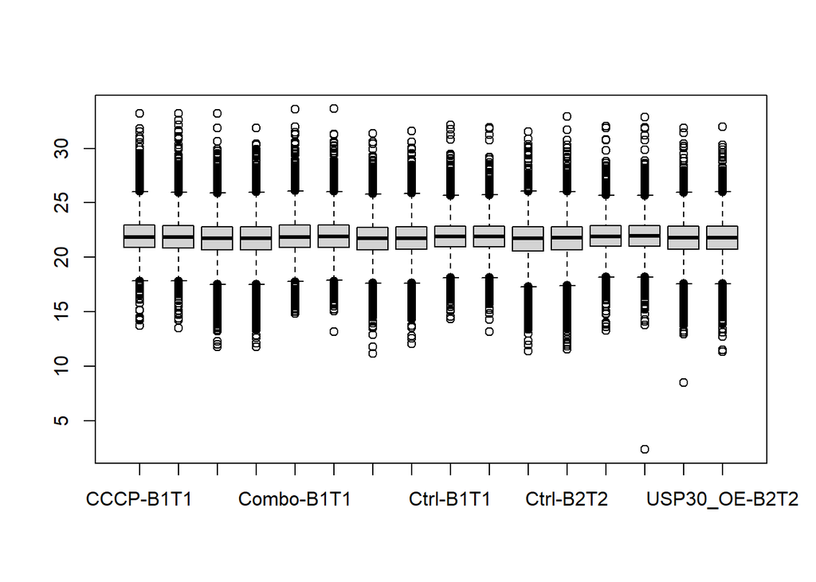

```r
boxplot(assay(pe[["ptmMSstats"]]))
```

MSstats input data normalisation (PTM)

### 2.2.2 Normalize PTM log intensity by protein log intensity

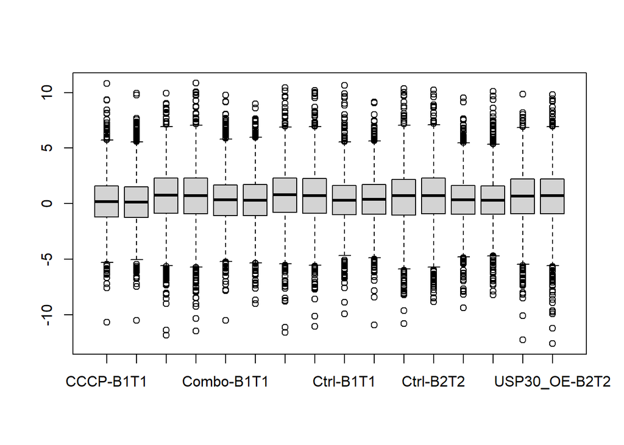

```r
#Only take ptms that have a parent protien
ptmWithProteinEvalue <- rowData(pe[["ptmMSstats"]])$PROTEIN %in% rownames(pe[["proteinMSstats"]])
ptmM <- pe[["ptmMSstats"]][ptmWithProteinEvalue,]
pe <- addAssay(pe,ptmM,"ptmMSstatsRel")
assay(pe[["ptmMSstatsRel"]]) <- assay(pe[["ptmMSstatsRel"]]) - assay(pe[["proteinMSstats"]])[rowData(pe[["ptmMSstatsRel"]])$PROTEIN,colnames(assay(pe[["ptmMSstatsRel"]]))]
boxplot(assay(pe[["ptmMSstatsRel"]]))
```

```r
pe
```

```
## An instance of class QFeatures containing 9 assays:
##  [1] peptidoformRaw: SummarizedExperiment with 18520 rows and 16 columns
##  [2] peptidoform: SummarizedExperiment with 18520 rows and 16 columns
##  [3] proteinRaw: SummarizedExperiment with 4988 rows and 16 columns
##  ...
##  [7] ptmMSstats: SummarizedExperiment with 10799 rows and 16 columns
##  [8] proteinMSstats: SummarizedExperiment with 2086 rows and 16 columns
##  [9] ptmMSstatsRel: SummarizedExperiment with 4508 rows and 16 columns
```

peptidoformRaw = raw peptidoform (log) intensities peptidoform = center median normalised peptidoform intensities ptmMSstats = ptm data according to MSstats summarisation proteinMSstats = protein data according to MSstats proteinRaw = peptidoformRaw -> protein proteinRobust = peptidoform -> protein pepformRel = peptidoform normalised for protein abundance ptmRel = ptm normalised for protein abundance when starting from raw data (typical msqrob2PTM workflow) ptmMSstatsRel = ptm normalised for protein abundance when starting from MSstats summarisation

```r
nrow(assay(pe[["ptmMSstatsRel"]]))
```

```
## [1] 4508
```

```r
nrow(assay(pe[["ptmRel"]]))
```

```
## [1] 8763
```

## 2.3 Analysis

### 2.3.1 Peptidoform analysis

Only possible when starting from the raw data

#### 2.3.1.1 Hypothesistest for each contrast

```r
pe <- msqrob2::msqrob(object = pe, i = "pepformRel", formula = ~group + (1|biorep), robust = F, overwrite = T)
```

[output not shown]

[output cut: 137 more lines]

[output not shown]

[output not shown]

[output cut: 123 more lines]

[output not shown]

[output not shown]

[output cut: 140 more lines]

[output not shown]

[output not shown]

[output cut: 124 more lines]

[output not shown]

[output not shown]

[output cut: 147 more lines]

[output not shown]

[output not shown]

[output cut: 133 more lines]

[output not shown]

```r
getCoef(rowData(pe[["pepformRel"]])$msqrobModels[[2]])
```

```
##                  (Intercept)                    groupCCCP
##                  0.386896499                  0.008369547
##                   groupCombo                groupUSP30_OE
##                  0.302448950                  0.275558844
##     (Intercept)biorepCCCP-B1     (Intercept)biorepCCCP-B2
##                  0.119560525                 -0.119560525
##    (Intercept)biorepCombo-B1    (Intercept)biorepCombo-B2
##                  0.295884657                 -0.295884657
##     (Intercept)biorepCtrl-B1     (Intercept)biorepCtrl-B2
##                  0.656978842                 -0.656978842
## (Intercept)biorepUSP30_OE-B1 (Intercept)biorepUSP30_OE-B2
##                  0.092963527                 -0.092963527
```

```r
contrasts <- c("groupCombo", "groupCCCP", "groupUSP30_OE", "groupCombo - groupCCCP",
               "groupCCCP - groupUSP30_OE", "groupCombo - groupUSP30_OE")
```

```r
L <- makeContrast(c("groupCombo = 0",
                    "groupCCCP = 0",
                    "groupUSP30_OE = 0",
                    "groupCombo - groupCCCP = 0",
                    "groupCCCP - groupUSP30_OE = 0",
                    "groupCombo - groupUSP30_OE = 0"),
                  parameterNames = rowData(pe[["pepformRel"]])$msqrobModels[[2]] %>%
                  getCoef %>%
                  names)
pe <- hypothesisTest(object = pe, i = "pepformRel", contrast = L, overwrite=T)
```

#### 2.3.1.2 Volcanoplot

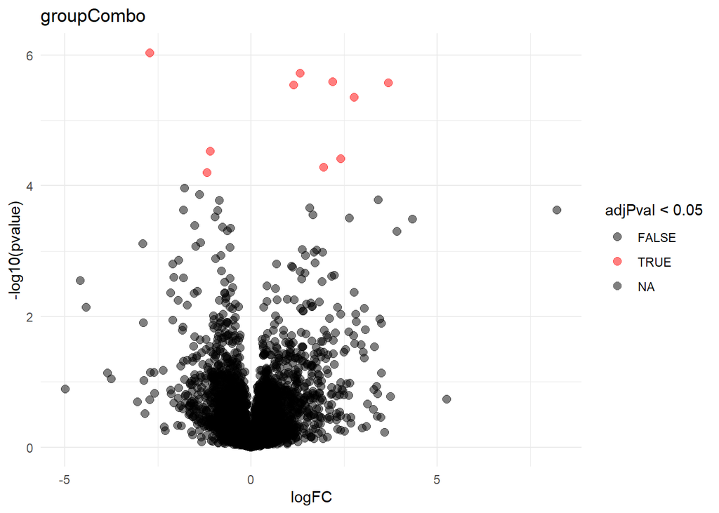

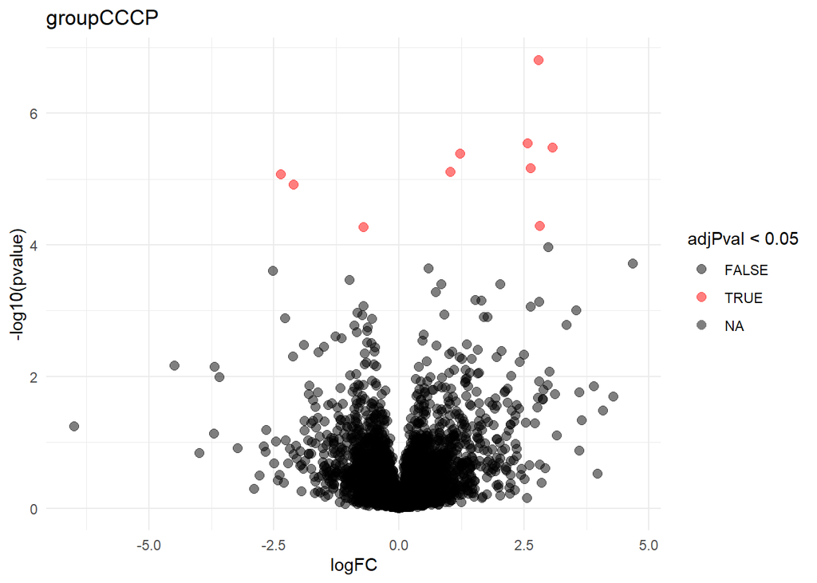

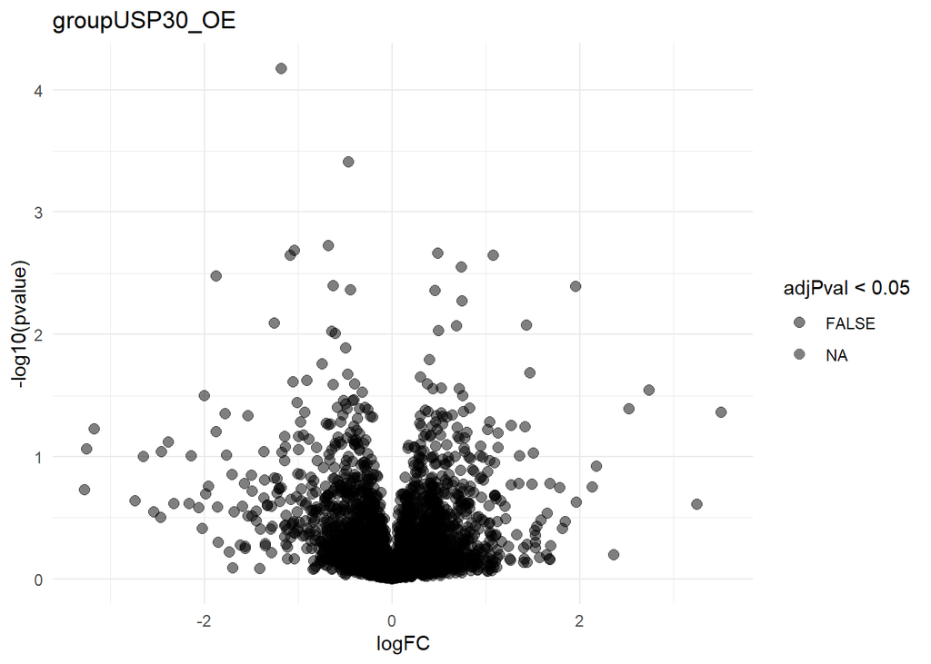

```
##
## $`groupCombo - groupCCCP`
```

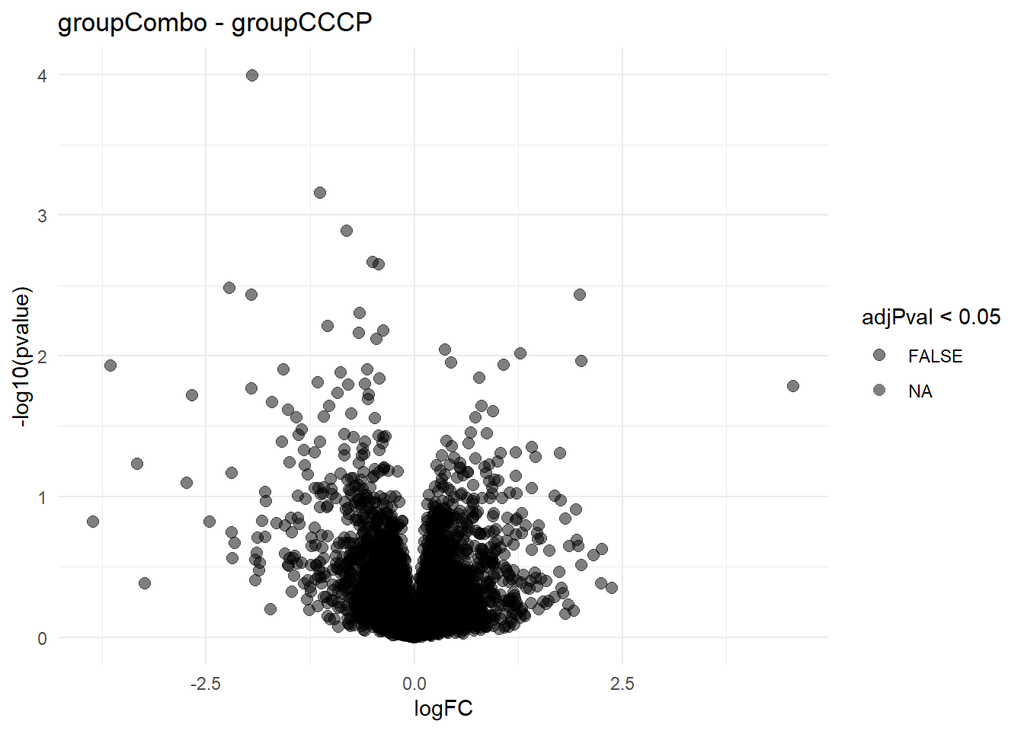

```
##
## $`groupCCCP - groupUSP30_OE`
```

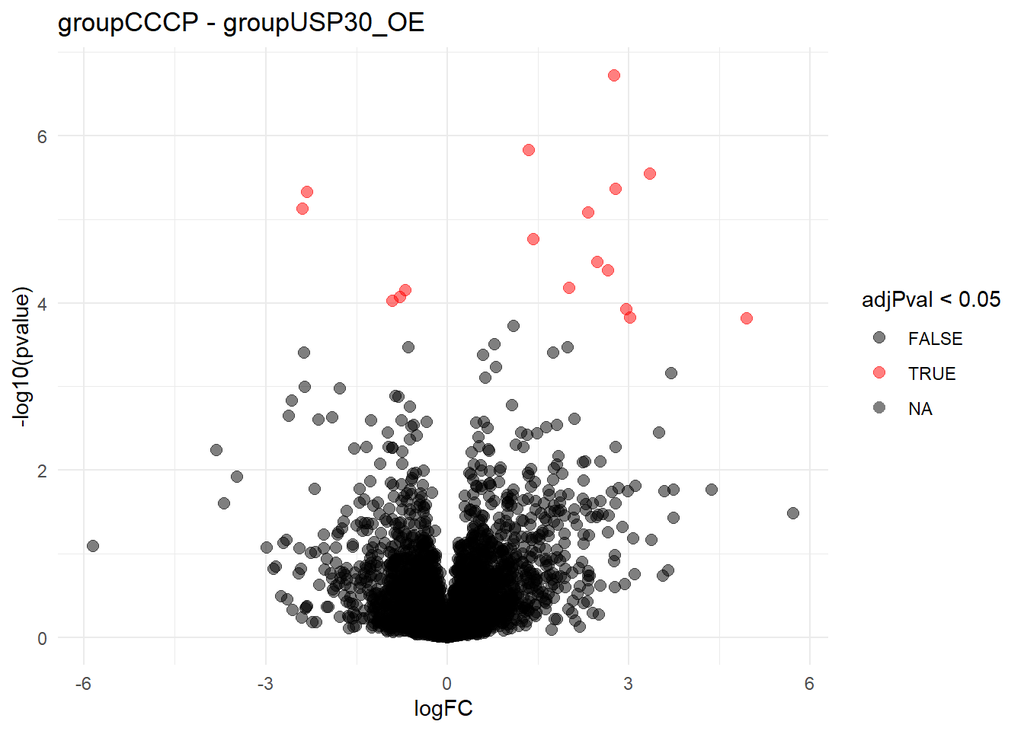

```
##
## $`groupCombo - groupUSP30_OE`
```

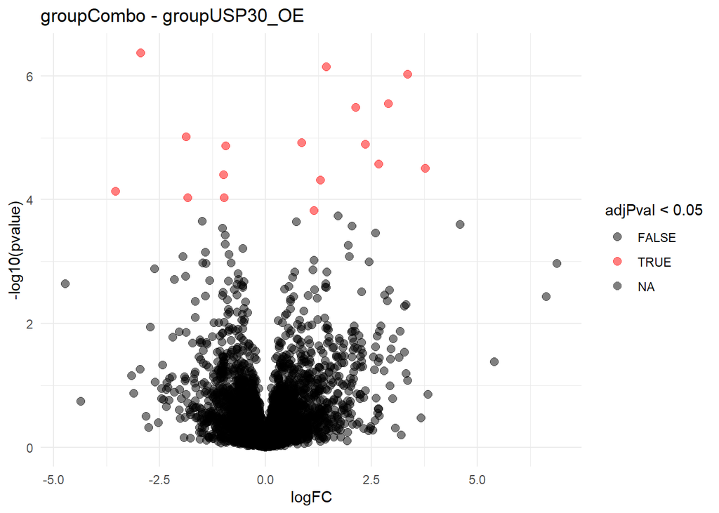

```r
volcano <- list()
for (contrast in contrasts){
volcano[[contrast]] <- rowData(pe[["pepformRel"]])[[contrast]]%>%
            ggplot(aes(x = logFC, y = -log10(pval),
                   color = adjPval < 0.05,
                   annotation=rowData(pe[["pepformRel"]])[,3])) +
  geom_point(cex = 2.5) +
  scale_color_manual(values = alpha(c("black", "red"), 0.5)) +
  theme_minimal() +
  ylab("-log10(pvalue)") +
  ggtitle(contrast)
}
volcano
```

#### 2.3.1.3 Significant peptidoforms for each contrast

```r
tables <- list()
for (contrast in contrasts){
sigTable <- rowData(pe[["pepformRel"]])[[contrast]]
if(nrow(sigTable %>%
  na.exclude %>%
  filter(adjPval<0.05)) > 0){
sigTable <- sigTable %>%
  na.exclude %>%
  filter(adjPval<0.05) %>%
  arrange(pval) %>%
  mutate(
    se = format(se, digits = 2),
    df = format(df, digits =2),
    t = format(t, digits = 2),
    adjPval = format(adjPval, digits = 3),
    rank = 1:length(logFC)
  )
sigTable_print <- sigTable %>% mutate(peptidoform = rownames(sigTable)) %>% gt() %>% tab_header(title = md(contrast))
tables[[contrast]] <- sigTable
}
#knitr::kable(sigTable, caption = contrast)
}
knitr::kable(tables)
```

|  | logFC | se | df | t | pval | adjPval | rank |
| --- | --- | --- | --- | --- | --- | --- | --- |
| SPVLVFQCNSR_2 | -2.724664 | 0.29 | 11 | -9.5 | 9.00e-07 | 0.00295 | 1 |
| MVLVGDVK*DR_2 | 1.316870 | 0.17 | 14 | 7.9 | 1.90e-06 | 0.00295 | 2 |
| LLGITK*ECVMR_3 | 2.185448 | 0.28 | 13 | 7.9 | 2.60e-06 | 0.00295 | 3 |
| HNEETGDNVGPLIIK*K_3 | 3.691093 | 0.41 | 11 | 9.0 | 2.70e-06 | 0.00295 | 4 |
| TNYNDRYDEIRR_4 | 1.136891 | 0.15 | 13 | 7.8 | 2.90e-06 | 0.00295 | 5 |
| GQISETLK*TR_2 | 2.769352 | 0.31 | 10 | 8.8 | 4.50e-06 | 0.00377 | 6 |
| YCEK*RDPHLACVAYER_4 | -1.097674 | 0.18 | 14 | -6.1 | 2.99e-05 | 0.02161 | 7 |
| VYFK*DTHPK_2 | 2.404704 | 0.38 | 12 | 6.3 | 3.87e-05 | 0.02447 | 8 |
| VSMLK*MDESTLLR_3 | 1.950830 | 0.34 | 14 | 5.8 | 5.27e-05 | 0.02963 | 9 |
| LVSK*SVFPEQANNNEWAR_3 | -1.190472 | 0.21 | 14 | -5.7 | 6.29e-05 | 0.03187 | 10 |

|  | logFC | se | df | t | pval | adjPval | rank |
| --- | --- | --- | --- | --- | --- | --- | --- |
| LLGITK*ECVMR_3 | 2.7994140 | 0.28 | 13 | 10.1 | 2.00e-07 | 0.000789 | 1 |
| VSMLK*MDESTLLR_3 | 2.5693550 | 0.34 | 14 | 7.6 | 2.90e-06 | 0.005217 | 2 |
| VYFK*DTHPK_2 | 3.0755393 | 0.38 | 12 | 8.0 | 3.40e-06 | 0.005217 | 3 |
| MVLVGDVK*DR_2 | 1.2305403 | 0.17 | 14 | 7.4 | 4.10e-06 | 0.005217 | 4 |
| GQISETLK*TR_2 | 2.6409077 | 0.31 | 10 | 8.4 | 6.90e-06 | 0.006160 | 5 |
| TNYNDRYDEIRR_4 | 1.0367708 | 0.15 | 13 | 7.1 | 7.80e-06 | 0.006160 | 6 |
| VNNSSLIGLGYTQTLKPGIK_3 | -2.3634265 | 0.31 | 12 | -7.5 | 8.50e-06 | 0.006160 | 7 |
| SPVLVFQCNSR_2 | -2.1011612 | 0.29 | 11 | -7.3 | 1.21e-05 | 0.007691 | 8 |
| HNEETGDNVGPLIIK*K_3 | 2.8183565 | 0.43 | 11 | 6.5 | 5.14e-05 | 0.027336 | 9 |
| QGAIVAVTGDGVNDSPALKK*_3 | -0.7113949 | 0.11 | 11 | -6.5 | 5.40e-05 | 0.027336 | 10 |

|  | logFC | se | df | t | pval | adjPval | rank |
| --- | --- | --- | --- | --- | --- | --- | --- |
| LLGITK*ECVMR_3 | 2.7536167 | 0.28 | 13.1 | 9.9 | 0.0000002 | 0.000957 | 1 |
| MVLVGDVK*DR_2 | 1.3480892 | 0.17 | 13.7 | 8.1 | 0.0000015 | 0.003730 | 2 |
| VYFK*DTHPK_2 | 3.3484600 | 0.41 | 12.1 | 8.2 | 0.0000029 | 0.004771 | 3 |
| GQISETLK*TR_2 | 2.7808401 | 0.31 | 10.2 | 8.8 | 0.0000043 | 0.004771 | 4 |
| SPVLVFQCNSR_2 | -2.3169252 | 0.29 | 11.4 | -8.1 | 0.0000047 | 0.004771 | 5 |
| VNNSSLIGLGYTQTLKPGIK_3 | -2.3952247 | 0.31 | 11.5 | -7.6 | 0.0000075 | 0.006029 | 6 |
| VSMLK*MDESTLLR_3 | 2.3314821 | 0.34 | 13.6 | 6.9 | 0.0000083 | 0.006029 | 7 |
| NHYLK*DIER_2 | 1.4252363 | 0.22 | 13.7 | 6.4 | 0.0000174 | 0.011002 | 8 |
| HNEETGDNVGPLIIK*K_3 | 2.4869523 | 0.36 | 10.7 | 6.8 | 0.0000322 | 0.018133 | 9 |
| LTLDTIFVPNTGK*K_2 | 2.6613796 | 0.41 | 11.1 | 6.5 | 0.0000407 | 0.020586 | 10 |
| NK*AVQLENELENFTK_3 | 2.0164796 | 0.36 | 13.7 | 5.6 | 0.0000658 | 0.029945 | 11 |
| QGAIVAVTGDGVNDSPALKK*_3 | -0.6889466 | 0.11 | 10.5 | -6.3 | 0.0000710 | 0.029945 | 12 |
| TVTNAVVTVPAYFNDSQR_3 | -0.7777782 | 0.14 | 13.2 | -5.6 | 0.0000856 | 0.033349 | 13 |
| HVVLYPLVAK_2 | -0.8989635 | 0.17 | 13.7 | -5.4 | 0.0000942 | 0.034063 | 14 |
| FKASGVEGADVVK*LLNK_4 | 2.9576878 | 0.51 | 11.0 | 5.8 | 0.0001200 | 0.040505 | 15 |
| LK*TALLDISCVK_3 | 3.0259097 | 0.45 | 8.0 | 6.7 | 0.0001503 | 0.045365 | 16 |
| NPEMLK*QWEYCGQPK_3 | 4.9479858 | 0.74 | 8.1 | 6.7 | 0.0001523 | 0.045365 | 17 |

|  | logFC | se | df | t | pval | adjPval | rank |
| --- | --- | --- | --- | --- | --- | --- | --- |
| SPVLVFQCNSR_2 | -2.9404279 | 0.29 | 11 | -10.3 | 0.0000004 | 0.00160 | 1 |
| MVLVGDVK*DR_2 | 1.4344191 | 0.17 | 14 | 8.6 | 0.0000007 | 0.00160 | 2 |
| HNEETGDNVGPLIIK*K_3 | 3.3596891 | 0.34 | 11 | 10.0 | 0.0000009 | 0.00160 | 3 |
| GQISETLK*TR_2 | 2.9092847 | 0.31 | 10 | 9.2 | 0.0000028 | 0.00329 | 4 |
| LLGITK*ECVMR_3 | 2.1396511 | 0.28 | 13 | 7.7 | 0.0000033 | 0.00329 | 5 |
| FFVGGNWK*MNGR_3 | -1.8645906 | 0.24 | 11 | -7.7 | 0.0000097 | 0.00762 | 6 |
| DDMIHQLPLLTEK*QYIATIHSR_5 | 0.8641407 | 0.13 | 14 | 6.7 | 0.0000120 | 0.00762 | 7 |
| NK*AVQLENELENFTK_3 | 2.3663028 | 0.36 | 14 | 6.6 | 0.0000128 | 0.00762 | 8 |
| TVTNAVVTVPAYFNDSQR_3 | -0.9356702 | 0.14 | 13 | -6.7 | 0.0000135 | 0.00762 | 9 |
| VYFK*DTHPK_2 | 2.6776249 | 0.41 | 12 | 6.5 | 0.0000269 | 0.01361 | 10 |
| LK*TALLDISCVK_3 | 3.7735938 | 0.45 | 8 | 8.4 | 0.0000312 | 0.01438 | 11 |
| HVVLYPLVAK_2 | -0.9806580 | 0.17 | 14 | -5.9 | 0.0000399 | 0.01686 | 12 |
| AK*IQDK_2 | 1.2944897 | 0.19 | 10 | 6.7 | 0.0000488 | 0.01900 | 13 |
| GRGDASGLK*R_2 | -3.5309762 | 0.61 | 13 | -5.8 | 0.0000736 | 0.02661 | 14 |
| YCEK*RDPHLACVAYER_4 | -0.9779669 | 0.18 | 14 | -5.4 | 0.0000941 | 0.02978 | 15 |
| VNNSSLIGLGYTQTLKPGIK_3 | -1.8258023 | 0.31 | 12 | -5.8 | 0.0000941 | 0.02978 | 16 |
| NHYLK*DIER_2 | 1.1472465 | 0.22 | 14 | 5.2 | 0.0001501 | 0.04472 | 17 |

### 2.3.2 PTM level analysis

```r
pe <- msqrob2::msqrob(object = pe, i = "ptmRel", formula = ~group+(1|biorep), robust=TRUE, overwrite = T)
```

[output not shown]

[output cut: 224 more lines]

[output not shown]

[output not shown]

[output cut: 180 more lines]

[output not shown]

[output not shown]

[output cut: 167 more lines]

[output not shown]

[output not shown]

[output cut: 181 more lines]

[output not shown]

[output not shown]

[output cut: 194 more lines]

[output not shown]

[output not shown]

[output cut: 135 more lines]

[output not shown]

```r
pe <- msqrob2::msqrob(object = pe, i = "ptmMSstatsRel", formula = ~group+(1|biorep), robust=TRUE, overwrite = T)
```

[output not shown]

[output cut: 12 more lines]

[output not shown]

[output not shown]

[output not shown]

[output not shown]

[output not shown]

[output cut: 21 more lines]

[output not shown]

[output not shown]

```r
pe <- hypothesisTest(object = pe, i = "ptmMSstatsRel", contrast = L, overwrite = T)
pe <- hypothesisTest(object = pe, i = "ptmRel", contrast = L, overwrite = T)
```

### 2.3.3 Significant ptms for each contrast

```r
tables <- list()
for (contrast in contrasts){
sigTable <- rowData(pe[["ptmRel"]])[[contrast]]
if(nrow(sigTable %>%
  na.exclude %>%
  filter(adjPval<0.05))>0){
sigTable <- sigTable %>%
  na.exclude %>%
  filter(adjPval<0.05) %>%
  arrange(pval) %>%
  mutate(
    se = format(se, digits = 2),
    df = format(df, digits =2),
    t = format(t, digits = 2),
    adjPval = format(adjPval, digits = 3),
    rank = 1:length(logFC)
  )
sigTable_print <- sigTable %>% mutate(peptidoform = rownames(sigTable)) %>% gt() %>% tab_header(title = md(contrast))
tables[[contrast]] <- sigTable
}
}
knitr::kable(tables)
```

|  | logFC | se | df | t | pval | adjPval | rank |
| --- | --- | --- | --- | --- | --- | --- | --- |
| O94826_K078 | -2.8127210 | 0.361 | 12.6 | -7.8 | 0.0000037 | 0.00577 | 1 |
| O94826_K300 | -4.1719035 | 0.561 | 13.6 | -7.4 | 0.0000039 | 0.00577 | 2 |
| Q15154_K0970 | -0.8732012 | 0.122 | 13.6 | -7.2 | 0.0000058 | 0.00577 | 3 |
| Q00610_K0911 | -1.1501636 | 0.158 | 12.8 | -7.3 | 0.0000066 | 0.00577 | 4 |
| P00387_K115 | 2.2464142 | 0.327 | 13.0 | 6.9 | 0.0000115 | 0.00732 | 5 |
| Q9UHP3_K0201 | -0.7264040 | 0.106 | 12.9 | -6.8 | 0.0000126 | 0.00732 | 6 |
| O94826_K168 | 1.6535096 | 0.237 | 11.4 | 7.0 | 0.0000196 | 0.00974 | 7 |
| Q9Y490_K0334 | 2.1589443 | 0.319 | 11.7 | 6.8 | 0.0000233 | 0.01010 | 8 |
| P19367_K501 | -3.1090527 | 0.462 | 9.8 | -6.7 | 0.0000559 | 0.01829 | 9 |
| P56937_K321 | 1.6172115 | 0.264 | 11.7 | 6.1 | 0.0000569 | 0.01829 | 10 |
| P05023_K0727 | -0.5567967 | 0.088 | 10.7 | -6.4 | 0.0000615 | 0.01829 | 11 |
| P61247_K056 | -0.8474852 | 0.149 | 13.6 | -5.7 | 0.0000632 | 0.01829 | 12 |
| P21333_K0906 | -0.5371851 | 0.096 | 13.6 | -5.6 | 0.0000714 | 0.01909 | 13 |
| Q14566_K611 | 1.0474923 | 0.189 | 12.4 | 5.5 | 0.0001141 | 0.02451 | 14 |
| Q9NZ45_K089 | 1.3922460 | 0.248 | 11.7 | 5.6 | 0.0001219 | 0.02451 | 15 |
| P52789_K041 | 1.2938089 | 0.237 | 12.6 | 5.5 | 0.0001239 | 0.02451 | 16 |
| O43242_K273 | -1.1294591 | 0.211 | 13.1 | -5.4 | 0.0001256 | 0.02451 | 17 |
| Q969Z3_K294 | 3.3928942 | 0.585 | 10.8 | 5.8 | 0.0001270 | 0.02451 | 18 |
| Q13332_K1685 | -1.8299144 | 0.305 | 10.0 | -6.0 | 0.0001341 | 0.02452 | 19 |
| P46781_K121 | -1.5983486 | 0.282 | 11.0 | -5.7 | 0.0001434 | 0.02491 | 20 |
| P14618_K207 | 0.5359283 | 0.104 | 13.6 | 5.1 | 0.0001673 | 0.02768 | 21 |
| Q99613_K712 | -0.8223667 | 0.154 | 11.9 | -5.3 | 0.0001837 | 0.02901 | 22 |
| P54920_K227 | 1.5111201 | 0.304 | 13.6 | 5.0 | 0.0002237 | 0.03260 | 23 |
| P05023_K0671 | 4.0617692 | 0.816 | 13.5 | 5.0 | 0.0002252 | 0.03260 | 24 |
| P36578_K106 | -0.5942681 | 0.118 | 12.2 | -5.0 | 0.0002845 | 0.03805 | 25 |
| P61978_K052 | -0.7458891 | 0.148 | 11.9 | -5.0 | 0.0002929 | 0.03805 | 26 |
| P46777_K027 | -0.9503903 | 0.183 | 10.9 | -5.2 | 0.0003083 | 0.03805 | 27 |
| Q13485_K070 | 1.2135791 | 0.254 | 13.6 | 4.8 | 0.0003170 | 0.03805 | 28 |
| Q8WXW3_K708 | -0.9758843 | 0.197 | 12.2 | -4.9 | 0.0003207 | 0.03805 | 29 |
| P60174_K051 | -1.3728847 | 0.264 | 10.6 | -5.2 | 0.0003286 | 0.03805 | 30 |

|  | logFC | se | df | t | pval | adjPval | rank |
| --- | --- | --- | --- | --- | --- | --- | --- |
| Q9Y490_K0334 | 2.7679550 | 0.320 | 11.7 | 8.7 | 0.0000020 | 0.00550 | 1 |
| O94826_K168 | 1.9708739 | 0.237 | 11.4 | 8.3 | 0.0000036 | 0.00550 | 2 |
| O94826_K300 | -3.4468125 | 0.476 | 13.6 | -7.2 | 0.0000052 | 0.00550 | 3 |
| Q15154_K0970 | -0.8800041 | 0.125 | 13.6 | -7.1 | 0.0000069 | 0.00550 | 4 |
| P05023_K0727 | -0.7106736 | 0.089 | 10.7 | -8.0 | 0.0000079 | 0.00550 | 5 |
| P14618_K207 | 0.7115917 | 0.104 | 13.6 | 6.8 | 0.0000098 | 0.00570 | 6 |
| Q9UHP3_K0201 | -0.6815926 | 0.104 | 12.9 | -6.5 | 0.0000194 | 0.00935 | 7 |
| P61247_K056 | -0.9655925 | 0.153 | 13.6 | -6.3 | 0.0000215 | 0.00935 | 8 |
| P19367_K501 | -3.0705713 | 0.462 | 9.8 | -6.6 | 0.0000620 | 0.02391 | 9 |
| Q9BYC9_K114 | 1.6098818 | 0.266 | 11.5 | 6.0 | 0.0000694 | 0.02410 | 10 |
| P00387_K115 | 1.9418734 | 0.351 | 13.0 | 5.5 | 0.0000972 | 0.03071 | 11 |
| Q14566_K611 | 1.0583253 | 0.197 | 12.4 | 5.4 | 0.0001496 | 0.04332 | 12 |

|  | logFC | se | df | t | pval | adjPval | rank |
| --- | --- | --- | --- | --- | --- | --- | --- |
| O94826_K078 | -2.643812 | 0.33 | 13 | -7.9 | 3.1e-06 | 0.0109 | 1 |

|  | logFC | se | df | t | pval | adjPval | rank |
| --- | --- | --- | --- | --- | --- | --- | --- |
| Q9Y490_K0334 | 2.7486618 | 0.310 | 12 | 8.9 | 0.0000016 | 0.00561 | 1 |
| O94826_K300 | -3.5901472 | 0.476 | 14 | -7.5 | 0.0000033 | 0.00572 | 2 |
| P05023_K0727 | -0.6821207 | 0.088 | 11 | -7.8 | 0.0000104 | 0.01024 | 3 |
| Q15154_K0970 | -0.8368161 | 0.125 | 14 | -6.7 | 0.0000118 | 0.01024 | 4 |
| O94826_K168 | 1.6424461 | 0.232 | 11 | 7.1 | 0.0000173 | 0.01202 | 5 |
| Q99460_K110 | 0.4704791 | 0.079 | 14 | 6.0 | 0.0000385 | 0.02147 | 6 |
| Q9Y277_K053 | 2.8522795 | 0.439 | 11 | 6.5 | 0.0000433 | 0.02147 | 7 |
| P21333_K0906 | -0.5173119 | 0.091 | 14 | -5.7 | 0.0000652 | 0.02829 | 8 |
| Q9Y277_K109 | 2.6684970 | 0.487 | 14 | 5.5 | 0.0000904 | 0.03491 | 9 |
| P00387_K115 | 1.9995407 | 0.366 | 13 | 5.5 | 0.0001076 | 0.03739 | 10 |
| O75121_K226 | 0.8158050 | 0.146 | 12 | 5.6 | 0.0001368 | 0.04076 | 11 |
| Q8IWA4_K718 | 2.0399595 | 0.380 | 13 | 5.4 | 0.0001408 | 0.04076 | 12 |
| Q14498_K178 | -0.6101128 | 0.120 | 14 | -5.1 | 0.0001862 | 0.04975 | 13 |

|  | logFC | se | df | t | pval | adjPval | rank |
| --- | --- | --- | --- | --- | --- | --- | --- |
| O94826_K078 | -3.3544927 | 0.335 | 12.6 | -10.0 | 0.0000002 | 0.000839 | 1 |
| O94826_K300 | -4.3152382 | 0.561 | 13.6 | -7.7 | 0.0000027 | 0.004606 | 2 |
| Q99460_K110 | 0.5451551 | 0.074 | 13.6 | 7.4 | 0.0000043 | 0.004930 | 3 |
| Q15459_K487 | 1.4225640 | 0.200 | 13.6 | 7.1 | 0.0000061 | 0.005281 | 4 |
| Q15154_K0970 | -0.8300132 | 0.122 | 13.6 | -6.8 | 0.0000100 | 0.006919 | 5 |
| P00387_K115 | 2.3040815 | 0.343 | 13.0 | 6.7 | 0.0000142 | 0.007611 | 6 |
| Q00610_K0911 | -0.9779669 | 0.146 | 12.8 | -6.7 | 0.0000153 | 0.007611 | 7 |
| Q9Y490_K0334 | 2.1396511 | 0.310 | 11.7 | 6.9 | 0.0000190 | 0.008113 | 8 |
| P21333_K0906 | -0.5904570 | 0.093 | 13.6 | -6.3 | 0.0000210 | 0.008113 | 9 |
| P60174_K051 | -1.8540337 | 0.264 | 10.6 | -7.0 | 0.0000263 | 0.009137 | 10 |
| P52789_K041 | 1.3442669 | 0.227 | 12.6 | 5.9 | 0.0000572 | 0.018066 | 11 |
| Q8IWA4_K718 | 2.2196955 | 0.380 | 12.7 | 5.8 | 0.0000644 | 0.018649 | 12 |
| P05023_K0727 | -0.5282438 | 0.086 | 10.7 | -6.1 | 0.0000871 | 0.023267 | 13 |
| P11940_K284 | -0.7228558 | 0.134 | 13.6 | -5.4 | 0.0001038 | 0.025382 | 14 |
| Q9Y277_K053 | 2.5424580 | 0.439 | 11.1 | 5.8 | 0.0001182 | 0.025382 | 15 |
| O94826_K168 | 1.3250818 | 0.232 | 11.4 | 5.7 | 0.0001209 | 0.025382 | 16 |
| Q9UHP3_K0201 | -0.5784178 | 0.107 | 12.9 | -5.4 | 0.0001242 | 0.025382 | 17 |
| Q99613_K712 | -0.8407119 | 0.152 | 11.9 | -5.5 | 0.0001360 | 0.026244 | 18 |
| P62829_K043 | -0.8329962 | 0.151 | 11.6 | -5.5 | 0.0001509 | 0.027600 | 19 |
| P36578_K106 | -0.6081563 | 0.117 | 12.2 | -5.2 | 0.0002211 | 0.036866 | 20 |
| Q6P1J9_K209 | 0.6893530 | 0.138 | 13.6 | 5.0 | 0.0002229 | 0.036866 | 21 |
| Q14152_K0603 | -0.7540783 | 0.149 | 12.6 | -5.1 | 0.0002392 | 0.037766 | 22 |
| P46777_K276 | -1.4894266 | 0.281 | 10.7 | -5.3 | 0.0002699 | 0.040760 | 23 |
| P19367_K501 | -2.4967634 | 0.456 | 9.8 | -5.5 | 0.0002866 | 0.041487 | 24 |

```r
tables <- list()
for (contrast in contrasts){
sigTable <- rowData(pe[["ptmMSstatsRel"]])[[contrast]]
if(nrow(sigTable %>%
  na.exclude %>%
  filter(adjPval<0.05))>0){
sigTable <- sigTable %>%
  na.exclude %>%
  filter(adjPval<0.05) %>%
  arrange(pval) %>%
  mutate(
    se = format(se, digits = 2),
    df = format(df, digits =2),
    t = format(t, digits = 2),
    adjPval = format(adjPval, digits = 3),
    rank = 1:length(logFC)
  )
sigTable_print <- sigTable %>% mutate(peptidoform = rownames(sigTable)) %>% gt() %>% tab_header(title = md(contrast))
tables[[contrast]] <- sigTable
}
}
knitr::kable(tables)
```

|  | logFC | se | df | t | pval | adjPval | rank |
| --- | --- | --- | --- | --- | --- | --- | --- |
| Q07955_K138 | -1.6569941 | 0.22 | 14 | -7.6 | 0.0000023 | 0.00209 | 1 |
| Q14683_K0536 | -1.0396070 | 0.14 | 14 | -7.2 | 0.0000043 | 0.00209 | 2 |
| P46781_K066 | -2.1285867 | 0.30 | 14 | -7.0 | 0.0000060 | 0.00209 | 3 |
| Q9Y277_K053 | 5.0776313 | 0.62 | 10 | 8.2 | 0.0000073 | 0.00209 | 4 |
| P23396_K075 | -1.7617234 | 0.25 | 13 | -7.0 | 0.0000089 | 0.00209 | 5 |
| P23396_K062 | -1.5079489 | 0.23 | 14 | -6.5 | 0.0000141 | 0.00276 | 6 |
| Q07020_K049 | -2.4182022 | 0.37 | 12 | -6.6 | 0.0000292 | 0.00489 | 7 |
| P32969_K121 | -1.8074314 | 0.33 | 13 | -5.4 | 0.0001033 | 0.01515 | 8 |
| P62736_K328 | -0.8295113 | 0.16 | 13 | -5.3 | 0.0001463 | 0.01907 | 9 |
| O60361_K109 | 2.9242816 | 0.55 | 11 | 5.3 | 0.0002236 | 0.02622 | 10 |
| P53621_K0825 | 1.9343065 | 0.41 | 13 | 4.7 | 0.0004048 | 0.04316 | 11 |

|  | logFC | se | df | t | pval | adjPval | rank |
| --- | --- | --- | --- | --- | --- | --- | --- |
| Q9Y277_K053 | 6.5140276 | 0.61 | 10 | 10.7 | 0.0000006 | 0.000734 | 1 |
| Q14683_K0536 | -0.9639974 | 0.15 | 14 | -6.3 | 0.0000184 | 0.010786 | 2 |
| P23396_K075 | -1.5120371 | 0.27 | 13 | -5.6 | 0.0000787 | 0.022940 | 3 |
| P11142_K071 | 0.8599653 | 0.16 | 14 | 5.4 | 0.0000842 | 0.022940 | 4 |
| O60361_K109 | 3.1968999 | 0.54 | 11 | 5.9 | 0.0000978 | 0.022940 | 5 |
| P46781_K066 | -1.5424815 | 0.30 | 14 | -5.2 | 0.0001349 | 0.026365 | 6 |
| P62263_K063 | -1.3743105 | 0.25 | 11 | -5.6 | 0.0001735 | 0.028575 | 7 |
| P23396_K062 | -1.1970786 | 0.24 | 14 | -5.0 | 0.0002183 | 0.028575 | 8 |
| P51003_K110 | -1.3986002 | 0.28 | 14 | -5.0 | 0.0002192 | 0.028575 | 9 |

|  | logFC | se | df | t | pval | adjPval | rank |
| --- | --- | --- | --- | --- | --- | --- | --- |
| Q9Y277_K053 | 6.896720 | 0.61 | 10 | 11.4 | 0.0000003 | 0.000397 | 1 |
| Q14683_K0536 | -1.266108 | 0.15 | 14 | -8.3 | 0.0000009 | 0.000527 | 2 |
| O60361_K109 | 4.519032 | 0.55 | 11 | 8.1 | 0.0000047 | 0.001789 | 3 |
| P11142_K071 | 1.062365 | 0.15 | 14 | 7.0 | 0.0000061 | 0.001789 | 4 |
| P0DMV8_K088 | 1.441307 | 0.25 | 14 | 5.8 | 0.0000480 | 0.010912 | 5 |
| P23396_K075 | -1.563001 | 0.27 | 13 | -5.8 | 0.0000558 | 0.010912 | 6 |
| P62263_K063 | -1.395891 | 0.25 | 11 | -5.6 | 0.0001557 | 0.023000 | 7 |
| P23396_K062 | -1.228960 | 0.24 | 14 | -5.1 | 0.0001713 | 0.023000 | 8 |
| P32969_K121 | -1.775512 | 0.35 | 13 | -5.1 | 0.0001765 | 0.023000 | 9 |
| P51003_K110 | -1.307818 | 0.28 | 14 | -4.6 | 0.0004275 | 0.048284 | 10 |
| Q14683_K0508 | -1.463424 | 0.32 | 14 | -4.6 | 0.0004528 | 0.048284 | 11 |

|  | logFC | se | df | t | pval | adjPval | rank |
| --- | --- | --- | --- | --- | --- | --- | --- |
| Q14683_K0536 | -1.3417180 | 0.15 | 14 | -9.2 | 0.0000002 | 0.000267 | 1 |
| Q07955_K138 | -1.6713486 | 0.21 | 14 | -7.8 | 0.0000018 | 0.001029 | 2 |
| Q9Y277_K053 | 5.4603240 | 0.61 | 10 | 8.9 | 0.0000035 | 0.001376 | 3 |
| P23396_K075 | -1.8126871 | 0.25 | 13 | -7.2 | 0.0000064 | 0.001875 | 4 |
| O60361_K109 | 4.2464135 | 0.56 | 11 | 7.6 | 0.0000093 | 0.002184 | 5 |
| P23396_K062 | -1.5398299 | 0.23 | 14 | -6.7 | 0.0000113 | 0.002203 | 6 |
| P32969_K121 | -2.0511635 | 0.34 | 13 | -6.1 | 0.0000342 | 0.005730 | 7 |
| Q07020_K049 | -2.3022481 | 0.37 | 12 | -6.3 | 0.0000460 | 0.006747 | 8 |
| P46781_K066 | -1.6942295 | 0.31 | 14 | -5.5 | 0.0000813 | 0.010597 | 9 |
| O60260_K369 | 1.5393949 | 0.28 | 13 | 5.5 | 0.0001104 | 0.012955 | 10 |
| P00338_K126 | -0.6211538 | 0.13 | 14 | -4.7 | 0.0003579 | 0.038170 | 11 |
| P11142_K071 | 0.7297664 | 0.16 | 14 | 4.6 | 0.0004282 | 0.041854 | 12 |

```r
save(pe, file = "C:/Users/Nina/OneDrive - UGent/Documenten/Doctoraat/msqrobPTM/Datasets MSStats/Biological dataset Ubiquitination MSV000078977/Quant analysis Massive/pe_ubiquitin_msqrob.rda")
```

Significant ptms from MSstats analysis

```r
for (contrast in model_ptm$ADJUSTED.Model$Label %>% unique){
  print(contrast)
  print(model_ptm$ADJUSTED.Model %>% filter(Label==contrast, adj.pvalue <= 0.05, Adjusted == T))
}
```

```
## [1] "CCCP vs Combo"
##          Protein         Label     log2FC         SE     Tvalue        DF
##  1:  O43670_K100 CCCP vs Combo -0.9959383 0.17557284  -5.672508 11.882874
##  2:  O96000_K131 CCCP vs Combo -1.6969605 0.26906510  -6.306877  8.576492
##  3:  P05455_K037 CCCP vs Combo  1.1237845 0.08768325  12.816410  7.721305
##  4:  P06744_K116 CCCP vs Combo -1.5539636 0.26922467  -5.771995 11.842327
##  5:  P07355_K104 CCCP vs Combo -1.7377329 0.17411429  -9.980415  4.434565
##  6:  P11586_K150 CCCP vs Combo -0.7209633 0.12588581  -5.727121  9.195360
##  7:  P14618_K367 CCCP vs Combo -1.4305587 0.19849003  -7.207207 10.648861
##  8: P26640_K1262 CCCP vs Combo -1.3344673 0.21794468  -6.122964 10.023111
##  9:  P30153_K542 CCCP vs Combo -5.3482535 0.37404913 -14.298265  4.224825
## 10:  P31689_K105 CCCP vs Combo -2.6481145 0.51588273  -5.133171 10.585163
## 11: P33527_K0498 CCCP vs Combo  0.8910380 0.17032007   5.231550 12.999688
## 12:  P33993_K471 CCCP vs Combo -2.6964812 0.36507525  -7.386097 10.016490
## 13:  P40925_K214 CCCP vs Combo -1.5543360 0.24053715  -6.461937 12.800822
```

[output cut: 237 more lines]

We can see a lot higher number of significant ptms here.